# 3 EFA

YOUR NAME

2020-11-21

## EFA Example Class Assignment

What is in the dataset? Here’s the scale we are going to explore:

Below are some phrases describing people’s behaviors. Please use the rating scale below to describe how accurately each statement describes you. Describe yourself as you generally are now, not as you wish to be in the future. Describe yourself as you honestly see yourself in relation to other people of your gender and of roughly your same age. Please read each statement carefully, and then check the box that corresponds to your response.

Scale: very inaccurate, moderately inaccurate, neither inaccurate nor accurate, moderately accurate, very accurate

1. Believe in the importance of art.
2. Have a vivid imagination.
3. Tend to vote for liberal political candidates.
4. Carry the conversation to a higher level.
5. Enjoy hearing new ideas.
6. Enjoy thinking about things.
7. Can say things beautifully.
8. Enjoy wild flights of fantasy.
9. Get excited by new ideas.
10. Have a rich vocabulary.
11. Am not interested in abstract ideas.
12. Do not like art.
13. Avoid philosophical discussions.
14. Do not enjoy going to art museums.
15. Tend to vote for conservative political candidates.
16. Do not like poetry.
17. Rarely look for a deeper meaning in things.
18. Believe that too much tax money goes to support artists.
19. Am not interested in theoretical discussions.
20. Have difficulty understanding abstract ideas.

Import the dataset below.

```r
df = read.csv("assignment_efa.csv")
```

## Short Data Screening

Exclude missing cases from the dataset. Exclude the group variable from the analysis (you can drop the column).

## Number of Factors

Include a parallel analysis and scree plot.

```r
# summary(df)
nomiss = na.omit(df)
# summary(nomiss)
df = nomiss[, -ncol(nomiss)]
# summary(df)

library(psych)
library(GPArotation)
paraPara = fa.parallel(df, fm = "ml", fa = "fa")
```

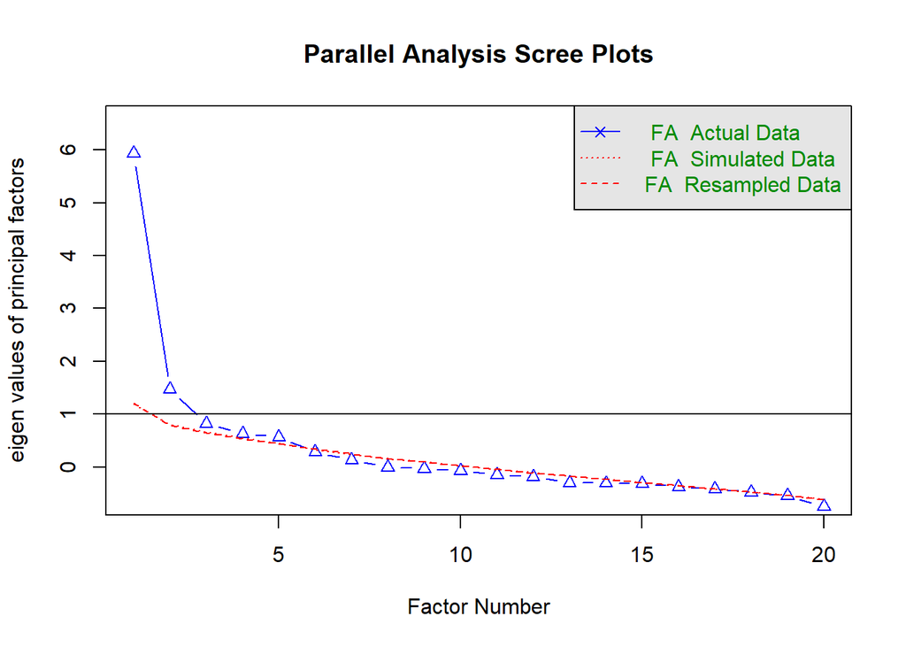

```
## Parallel analysis suggests that the number of factors =  5  and the number of components =  NA
```

```r
# 5 Factors
# 2 points above the line
```

Include a summary of the eigenvalues and the Kaiser criterion.

```r
Old_man_Kaiser = sum(paraPara$fa.values > 1)
New_man_Kaiser = sum(paraPara$fa.values > 0.7)
cat("Eigen Values in Old Kaiser criterion", Old_man_Kaiser)
```

```
## Eigen Values in Old Kaiser criterion 2
```

```r
cat("Eigen Values in new New Kaiser criterion", New_man_Kaiser)
```

```
## Eigen Values in new New Kaiser criterion 3
```

QUESTION: How many factors should you use given the results of the parallel analysis, scree plot, and eigenvalues? ANSWER: 2, because we know the answer from the lecture.

## Simple Structure

Using oblimin rotation and maximum likelihood as your math, run the EFA analysis. Examine the loadings. If you find items that do not load or cross load on multiple factors, you should exclude them.

```r
maxLike = fa(df, nfactors = 2, rotate = "oblimin", fm = "ml")
maxLike = fa(df[,-c(3,11,15,16)], nfactors = 2, rotate = "oblimin", fm = "ml")
maxLike
```

```
## Factor Analysis using method =  ml
## Call: fa(r = df[, -c(3, 11, 15, 16)], nfactors = 2, rotate = "oblimin",
##     fm = "ml")
## Standardized loadings (pattern matrix) based upon correlation matrix
##       ML2   ML1   h2   u2 com
## o1  -0.14 -0.91 0.75 0.25 1.0
## o2   0.18 -0.43 0.29 0.71 1.3
## o4   0.37  0.00 0.14 0.86 1.0
## o5   0.76  0.01 0.58 0.42 1.0
## o6   0.75  0.13 0.50 0.50 1.1
## o7   0.35 -0.03 0.13 0.87 1.0
## o8   0.34 -0.13 0.17 0.83 1.3
## o9   0.69 -0.05 0.51 0.49 1.0
## o10  0.46 -0.20 0.34 0.66 1.4
## o12 -0.07  0.81 0.71 0.29 1.0
## o13 -0.47  0.02 0.23 0.77 1.0
## o14 -0.18  0.72 0.67 0.33 1.1
## o17 -0.49  0.19 0.36 0.64 1.3
## o18 -0.02  0.64 0.42 0.58 1.0
## o19 -0.47  0.02 0.23 0.77 1.0
## o20 -0.44  0.25 0.34 0.66 1.6
##
##                        ML2  ML1
## SS loadings           3.39 2.97
## Proportion Var        0.21 0.19
## Cumulative Var        0.21 0.40
## Proportion Explained  0.53 0.47
## Cumulative Proportion 0.53 1.00
##
##  With factor correlations of
##       ML2   ML1
## ML2  1.00 -0.43
## ML1 -0.43  1.00
##
## Mean item complexity =  1.1
## Test of the hypothesis that 2 factors are sufficient.
##
## The degrees of freedom for the null model are  120  and the objective function was  6.92 with Chi Square of  579.89
## The degrees of freedom for the model are 89  and the objective function was  1.78
##
## The root mean square of the residuals (RMSR) is  0.08
## The df corrected root mean square of the residuals is  0.1
##
## The harmonic number of observations is  91 with the empirical chi square  147.7  with prob <  9.3e-05
## The total number of observations was  91  with Likelihood Chi Square =  146.44  with prob <  0.00012
##
## Tucker Lewis Index of factoring reliability =  0.828
## RMSEA index =  0.083  and the 90 % confidence intervals are  0.059 0.109
## BIC =  -255.03
## Fit based upon off diagonal values = 0.94
## Measures of factor score adequacy
##                                                    ML2  ML1
## Correlation of (regression) scores with factors   0.93 0.95
## Multiple R square of scores with factors          0.86 0.90
## Minimum correlation of possible factor scores     0.71 0.79
```

## Fit Indices

Show the RMSR, RMSEA, TLI, and CFI fit indices.

```r
cat("RMSR value -->", maxLike$rms)
```

```
## RMSR value --> 0.08223522
```

```r
cat("RMSEA value -->", maxLike$RMSEA)
```

```
## RMSEA value --> 0.08348678 0.05924408 0.1087125 0.9
```

```r
cat("TLI value -->", maxLike$TLI)
```

```
## TLI value --> 0.8281537
```

```r
cat("CFI Value -->", 1-(maxLike$STATISTIC - maxLike$dof)/(maxLike$null.chisq - maxLike$null.dof))
```

```
## CFI Value --> 0.8751034
```

QUESTION: Interpret these fit indices. What do they tell you about your model? ANSWER: RMSR value is not great, it good. RMSEA value is also decent. TLI value should be close to 0.95 so this is bad, Similar story with CFI model.

## Reliablity

Calculate Cronbach’s alpha for each factor.

```r
alpha(df[,c(4:10, 13, 17, 19, 20)], check.keys = T)
```

```
##
## Reliability analysis
## Call: alpha(x = df[, c(4:10, 13, 17, 19, 20)], check.keys = T)
##
##   raw_alpha std.alpha G6(smc) average_r S/N   ase mean   sd median_r
##       0.82      0.83    0.85       0.3 4.8 0.027  3.7 0.58     0.29
##
##  lower alpha upper     95% confidence boundaries
## 0.77 0.82 0.88
##
##  Reliability if an item is dropped:
##      raw_alpha std.alpha G6(smc) average_r S/N alpha se var.r med.r
## o4        0.82      0.83    0.85      0.32 4.7    0.028 0.016  0.33
## o5        0.80      0.80    0.82      0.29 4.1    0.030 0.013  0.29
## o6        0.80      0.81    0.83      0.30 4.2    0.030 0.015  0.29
## o7        0.82      0.83    0.84      0.33 4.8    0.027 0.013  0.30
## o8        0.81      0.82    0.84      0.31 4.6    0.028 0.018  0.31
## o9        0.80      0.81    0.83      0.29 4.2    0.030 0.014  0.29
## o10       0.80      0.81    0.83      0.29 4.2    0.031 0.017  0.28
## o13-      0.80      0.81    0.82      0.30 4.2    0.031 0.015  0.29
## o17-      0.80      0.81    0.83      0.30 4.3    0.030 0.016  0.29
## o19-      0.81      0.81    0.83      0.30 4.4    0.030 0.015  0.29
## o20-      0.80      0.81    0.83      0.30 4.3    0.030 0.017  0.29
##
##  Item statistics
##       n raw.r std.r r.cor r.drop mean   sd
## o4   91  0.48  0.49  0.40   0.37  3.8 0.87
## o5   91  0.65  0.70  0.69   0.58  4.2 0.68
## o6   91  0.63  0.66  0.62   0.53  4.2 0.90
## o7   91  0.43  0.45  0.38   0.31  3.7 0.85
## o8   91  0.55  0.54  0.46   0.42  3.6 1.05
## o9   91  0.63  0.67  0.64   0.55  4.2 0.72
## o10  91  0.68  0.66  0.63   0.57  3.4 1.02
## o13- 91  0.69  0.65  0.62   0.57  3.4 1.15
## o17- 91  0.65  0.63  0.58   0.53  3.9 1.08
## o19- 91  0.63  0.60  0.55   0.51  3.4 1.12
## o20- 91  0.63  0.62  0.56   0.52  3.5 1.00
##
## Non missing response frequency for each item
##        1    2    3    4    5 miss
## o4  0.00 0.10 0.22 0.49 0.19    0
## o5  0.00 0.01 0.11 0.52 0.36    0
## o6  0.01 0.04 0.11 0.37 0.46    0
## o7  0.02 0.04 0.31 0.48 0.14    0
## o8  0.04 0.08 0.36 0.31 0.21    0
## o9  0.01 0.01 0.07 0.56 0.35    0
## o10 0.02 0.18 0.33 0.32 0.15    0
## o13 0.20 0.31 0.22 0.24 0.03    0
## o17 0.35 0.31 0.20 0.13 0.01    0
## o19 0.21 0.20 0.36 0.20 0.03    0
## o20 0.13 0.44 0.23 0.18 0.02    0
```

```r
alpha(df[,c(1,2,12,14,18)], check.keys = T)
```

```
##
## Reliability analysis
## Call: alpha(x = df[, c(1, 2, 12, 14, 18)], check.keys = T)
##
##   raw_alpha std.alpha G6(smc) average_r S/N   ase mean  sd median_r
##       0.85      0.85    0.84      0.53 5.6 0.023  2.4 0.9      0.5
##
##  lower alpha upper     95% confidence boundaries
## 0.81 0.85 0.9
##
##  Reliability if an item is dropped:
##     raw_alpha std.alpha G6(smc) average_r S/N alpha se  var.r med.r
## o1-      0.79      0.79    0.76      0.49 3.8    0.033 0.0160  0.46
## o2-      0.86      0.86    0.84      0.61 6.2    0.023 0.0106  0.60
## o12      0.80      0.80    0.76      0.50 3.9    0.034 0.0086  0.48
## o14      0.80      0.80    0.77      0.50 4.1    0.032 0.0152  0.47
## o18      0.84      0.83    0.81      0.55 4.9    0.026 0.0260  0.55
##
##  Item statistics
##      n raw.r std.r r.cor r.drop mean   sd
## o1- 91  0.86  0.85  0.82   0.76  2.4 1.13
## o2- 91  0.64  0.67  0.53   0.49  2.0 0.93
## o12 91  0.86  0.84  0.82   0.75  2.4 1.30
## o14 91  0.85  0.83  0.79   0.73  2.8 1.27
## o18 91  0.74  0.75  0.65   0.60  2.7 1.01
##
## Non missing response frequency for each item
##        1    2    3    4    5 miss
## o1  0.04 0.12 0.24 0.33 0.26    0
## o2  0.02 0.05 0.15 0.48 0.29    0
## o12 0.33 0.29 0.15 0.15 0.08    0
## o14 0.16 0.33 0.19 0.21 0.11    0
## o18 0.14 0.24 0.43 0.15 0.03    0
```

## Interpretation

Create a plot of the factors.

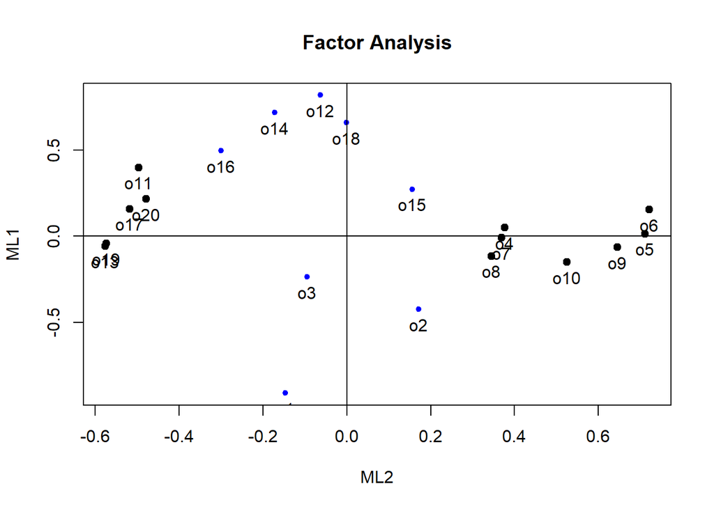

```r
efa = fa(df, nfactors = 2, rotate = "oblimin", fm = "ml")
fa.plot(efa, labels = colnames(df))
```